# Praca domowa 2

Ada Wojterska

## Dane

Dane wykorzystane w Pracy domowej 2 opisują wycenę nieruchmości. Każda obserwacja jest pewną nieruchmością, która posiada informacje takie jak powierzchnia, liczba pokoi, liczba łazienek i wiele więcj. Opis wszystkich kolumn w pliku `README.md`.

## Zadanie 1

Jak wygląda rozkład ceny nieruchomości w poszczególnych kodach pocztowych na przestrzeni lat? Rozważamy kody pocztowe, które mają więcej niż 280 posiadłości.

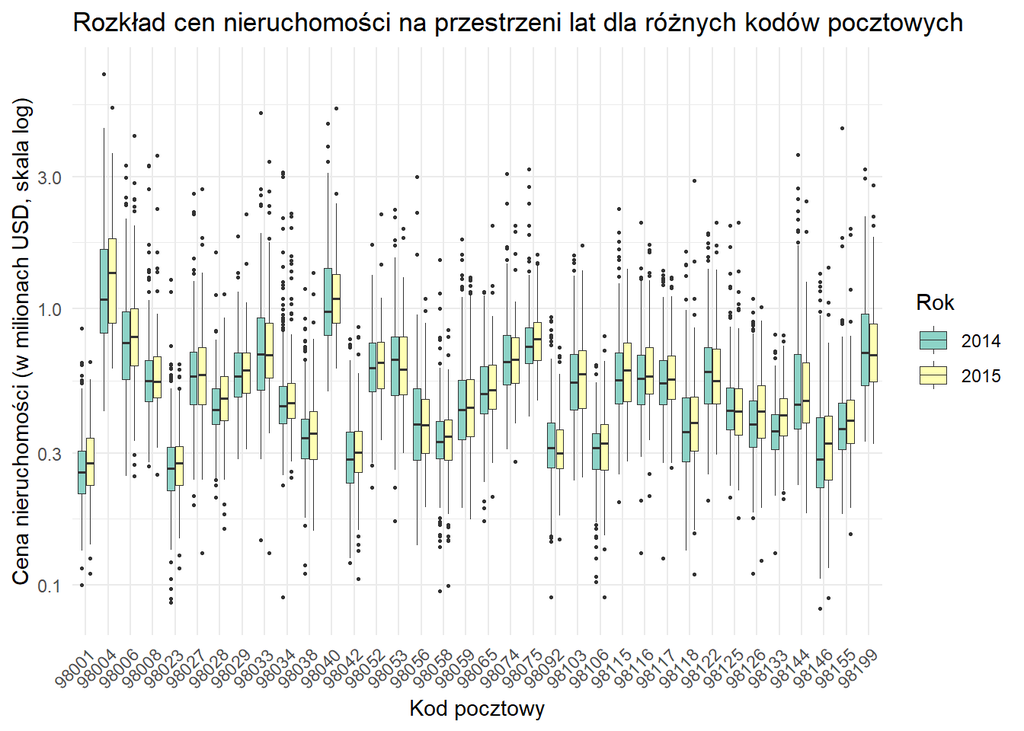

```r
zipcodes <- df %>%
  group_by(zipcode) %>%
  summarise(quantity = n()) %>%
  filter(quantity > 280) %>%
  pull(zipcode)

df1 <- df %>%
  filter(zipcode %in% zipcodes) %>%
  mutate(year_new = substr(date, 1, 4),
         price_millions = price / 1e6 )

ggplot(df1, aes(x = factor(zipcode), y = price_millions, fill = factor(year_new))) +
  geom_boxplot(size = 0.3, outlier.size = 0.5) +
  labs(title = "Rozkład cen nieruchomości na przestrzeni lat dla różnych kodów pocztowych",
       x = "Kod pocztowy",
       y = "Cena nieruchomości (w milionach USD, skala log)") +
  theme_minimal() +
  theme(axis.text.x = element_text(angle = 45, hjust = 1)) +
  scale_y_log10() +
  scale_fill_brewer(palette = "Set3", name = "Rok")
```

**Komentarz: Aby pokazać rozkład cen nieruchomości w poszczególnych kodach na przestrzeni lat wykorzystałam wykres boxplot. Skala logarytmiczna pozwala lepiej zobaczyć różnice pomiędzy danymi wynikami. Wyniki w latach 2014 i 2015 dla danego kodu pocztowego są w znaczącej większości przypadków bardzo podobne, choć zazwyczaj w 2015 roku ceny były nieco wyższe. Najwyższa mediana (około 1 mln USD) wystąpiła w regionach o kodach 98004 i 98040. Najniższe mediany oscylują wokoł 300 tys. USD dla kodów pocztowych 98001, 98023, 98042, 98092, 98146 (i kilka innych o delikatnie wyższej medianie).**

## Zadanie 2

Czy jest różnica w rozkładzie ceny nierchomości od powierzchni mieszkalnej uwzględniając podział na nieruchomości z piwnicą i bez?

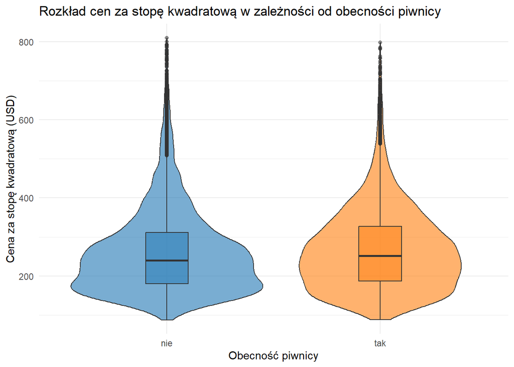

```r
df2 <- df %>%
  mutate(basement = ifelse(sqft_basement == 0, 0, 1)) %>%
  mutate(basement = as.factor(basement),
         price_millions = price / 1e6 ,
         price_per_sqft = price / sqft_living)

#wykres z osią x i osią y

# ggplot(df2, aes(x = sqft_living, y = price_millions, color = basement)) +
#   geom_point(size = 0.1) +  # Ustawienie przezroczystości
#   #geom_density_2d(aes(color = basement), size = 0.5, alpha = 0.5) +
#   labs(title = "Rozkład cen nieruchomości w zależności od powierzchni mieszkalnej",
#        y = "Cena nieruchomości (w milionach USD)",
#        x = "Powierzchnia mieszkalna") +
#   theme_minimal() +
#   scale_color_manual(values = c("#1f77b4", "#ff7f0e"),
#                      name = "Obecność piwnicy:",
#                      labels = c("nie", "tak")) +
#   guides(color = guide_legend(override.aes = list(size = 4))) +# Ustawienie legendy+
#   scale_y_log10() +
#   scale_x_log10()

ggplot(df2, aes(x = basement, y = price_per_sqft, fill = basement)) +
  geom_violin(alpha = 0.6) +  # Ustawienie przezroczystości dla violin plotu
  geom_boxplot(width = 0.2, alpha = 0.5) +  # Ustawienie przezroczystości dla boxplotu
  labs(title = "Rozkład cen za stopę kwadratową w zależności od obecności piwnicy",
       y = "Cena za stopę kwadratową (USD)",
       x = "Obecność piwnicy") +
  theme_minimal() +
  scale_fill_manual(values = c("#1f77b4", "#ff7f0e"),
                    guide = "none") +
  scale_x_discrete(labels = c("0" = "nie", "1" = "tak"))
```

**Komentarz: Wykorzystałam obliczenie ceny za 1 ft^2, aby wykres był bardziej czytelny, niż w przypadku wykorzystania dwóch zmiennych - ceny nieruchomości i powierzchni mieszkalnej. Cena za jednostkę powierzchni jest porównywalna w obu przypadkach, jednak w niewielkim stopniu wyższa w przypadku posiadania przez dom piwnicy. Widzimy np. delikatnie wyższą medianę. Cena za ft^2 w obu przypadkach w 75% przypadkach nie przekracza około 310-330 USD**

## Zadanie 3

Jaka jest zależność pomiędzy jakością wykończenia nieruchomości a liczbą pięter?

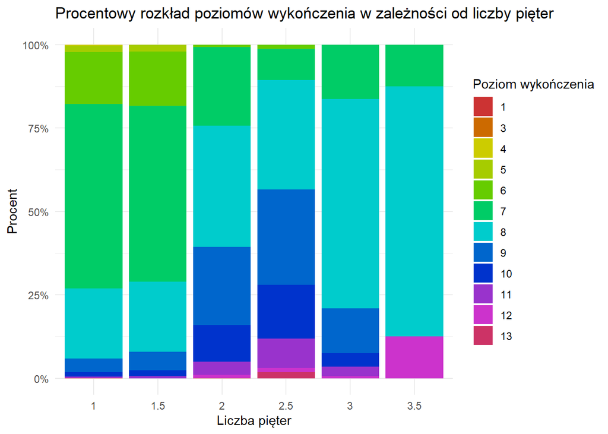

```r
df2 <- df

colors <- c(
  "#CC3333", # Czerwony (stonowany)
  "#CC6A00", # Pomarańczowy (stonowany)
  "#CCCC00", # Żółty (stonowany)
  "#A6CC00", # Jasnozielony (stonowany)
  "#66CC00", # Zielony (stonowany)
  "#00CC66", # Jasnozielony (stonowany)
  "#00CCCC", # Turkusowy (stonowany)
  "#0066CC", # Niebieski (stonowany)
  "#0033CC", # Niebieski (stonowany)
  "#9933CC", # Fioletowy (stonowany)
  "#CC33CC", # Magenta (stonowany)
  "#CC3366", # Różowy (stonowany)
  "#CCCCCC"  # Szary (stonowany zamiast białego)
)


ggplot(df2, aes(x = factor(floors), fill = factor(grade))) +
  geom_bar(position = "fill") +
  labs(title = "Procentowy rozkład poziomów wykończenia w zależności od liczby pięter",
       x = "Liczba pięter",
       y = "Procent") +
  theme_minimal() +
  scale_y_continuous(labels = scales::percent_format()) +
  scale_fill_manual(values = colors, name = "Poziom wykończenia")
```

**Komentarz: Z wykresu wynika, że wraz ze zwiększeniem liczby pięter zazwyczaj rośnie średni poziom wykończenia. W przypadku nieruchomości 1 i 1,5 piętrowych dominuje poziom 7, a np. w przypadku 3 i 3,5 piętrowych zdecydowanie już poziom 8. Znaczący procent nieruchomości o ocenie <= 6 zauważamy także tylko w przypadku nieruchomości 1 i 1,5 piętrowych. Co ciekawe, największy odsetek nieruchomości z oceną 9-10 zauważamy przy 2 i 2,5 piętrach.**

## Zadanie 4

Jaka jest zależność między powierzchnią mieszkalną nieruchomości a powierzchnią gruntu w podziale na liczbę sypialni?

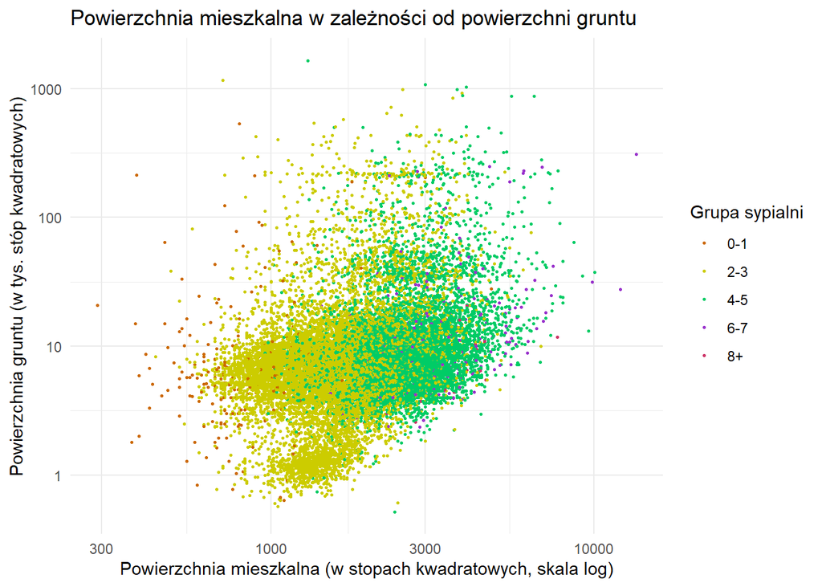

```r
df4 <- df

df4$bedroom_group <- cut(df4$bedrooms,
                          breaks = c(-Inf, 1, 3, 5, 7, Inf),
                          labels = c("0-1", "2-3", "4-5", "6-7", "8+"),
                          right = TRUE)

colors <- c(
  "#CC6A00",
  "#CCCC00",
  "#00CC66",
  "#9933CC",
  "#CC3366"
)

df4 <- df4 %>%
  mutate(sqft_lot_th = sqft_lot / 1000)

ggplot(df4, aes(x = sqft_living, y = sqft_lot_th, color = bedroom_group)) +
  geom_point(size = 0.5) +
  labs(title = "Powierzchnia mieszkalna w zależności od powierzchni gruntu",
       x = "Powierzchnia mieszkalna (w stopach kwadratowych, skala log)",
       y = "Powierzchnia gruntu (w tys. stóp kwadratowych)") +
  theme_minimal() +
  scale_y_log10() +  # Skala logarytmiczna dla osi y
  scale_x_log10() +  # Skala logarytmiczna dla osi x
  scale_color_manual(values = colors, name = "Grupa sypialni")
```

**Komentarz: Z wykresu możemy odczytać, że czym większa jest powierzchnia mieszkalna, tym większa jest powierzchnia gruntu, co jest zgodne z intuicją. Co więcej, im większa liczba sypialni w nieruchomości, tym większa jest powierzchnia gruntu i powierzchnia mieszkalna. Np. nieruchomości z 0-1 sypialni mają zazwyczaj poniżej 1000 stóp kwadratowych, a te mające od 6 sypialni mają zazwyczaj ponad 3000 stóp kwadratowych.**

## Zadanie 5

Rozważmy tylko nieruchomości, które miały remont. W której dekadzie było najwięcej przeprowadzonych remontów? Czy w poszczególnych dekadach jest porównywalny procent nieruchmości dla każdej wartości miary jakości i wykończenia nieruchomości?

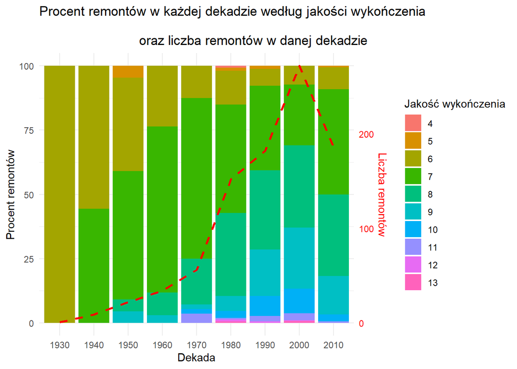

```r
#tylko remont
df5 <- df %>%
  filter(yr_renovated != 0) %>%
  mutate(decade = floor(yr_renovated / 10) * 10)

#liczenie w dekadach
ogolne_remonty <- df5 %>%
  group_by(decade) %>%
  summarise(total_remonty = n(), .groups = "drop")

df_remonty <- df5 %>%
  group_by(decade, grade) %>%
  summarise(count_remonty = n(), .groups = "drop") %>%
  group_by(decade) %>%
  mutate(percent_remonty = count_remonty / sum(count_remonty) * 100) %>%
  left_join(ogolne_remonty, by = "decade")

ggplot(df_remonty, aes(x = factor(decade), y = percent_remonty, fill = factor(grade))) +
  geom_bar(stat = "identity", position = "stack") +
  geom_line(aes(y = total_remonty / max(total_remonty) * 100, group = 1),
            color = "red", linewidth = 1, linetype = "dashed") +  # Linia ogólnej liczby remontów
  labs(title = "Procent remontów w każdej dekadzie według jakości wykończenia \n
                          oraz liczba remontów w danej dekadzie",
       x = "Dekada",
       y = "Procent remontów",
       fill = "Jakość wykończenia") +
  theme_minimal() +
    scale_y_continuous(sec.axis = sec_axis(~ . / 100 * max(ogolne_remonty$total_remonty),
                                           name = "Liczba remontów")) +  # Oś pomocnicza
  theme(axis.text.y.right = element_text(color = "red"),  # Ustaw kolor tekstu na prawej osi
        axis.title.y.right = element_text(color = "red"))
```

**Komentarz: Liczbę remontów obrazuje czerwony wykres liniowy na wykresie. Największa ich ilość była w latach 2000. Do lat 2000. rósł poziom wykończenia domów, w których odbywał się remont. W drugiej dekadzie XXI wieku sytuacja się zmieniła, a średni poziom wykończenia nieruchomości poddanej remontowi spadł w stosunku do wcześniejszej dekady.**

## Zadanie 6

Jak prezentuje się wartość minimalna, średnia i maksymalna ceny nieruchmości w podziele na rok budowy nieruchomości.

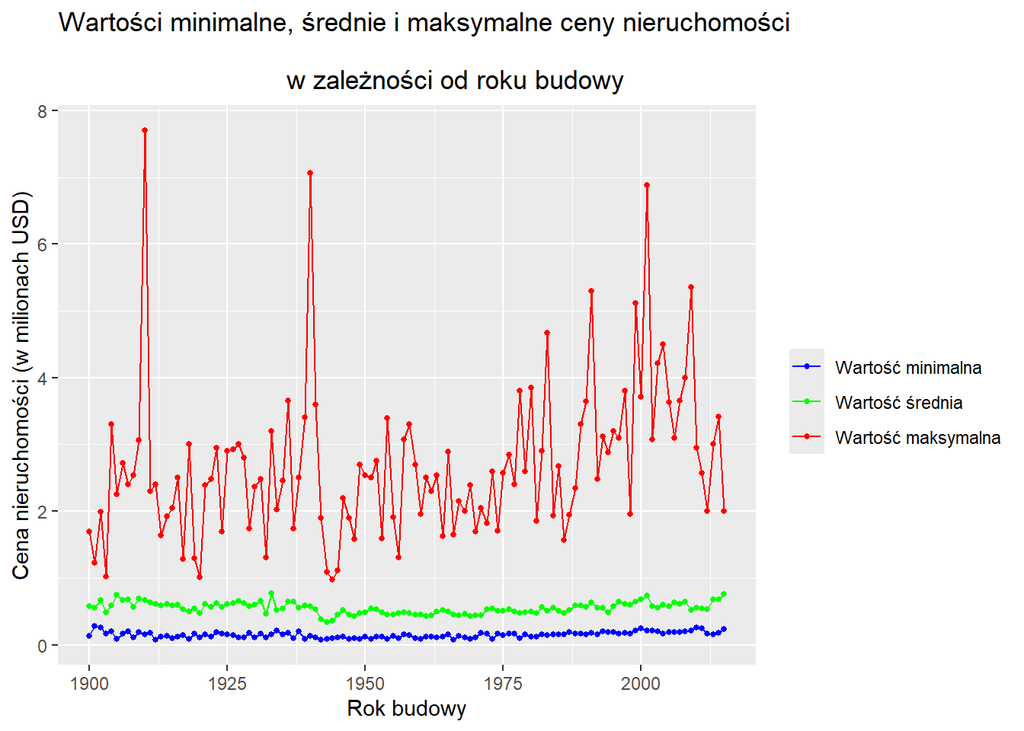

```r
ceny_statystyki <- df %>%
  group_by(yr_built) %>%
  summarise(
    min_price = min(price, na.rm = TRUE),
    avg_price = mean(price, na.rm = TRUE),
    max_price = max(price, na.rm = TRUE),
    .groups = "drop"
  )

# format dlugi
ceny_statystyki_long <- data.frame(
  yr_built = rep(ceny_statystyki$yr_built, times = 3),
  statystyka = rep(c("min_price", "avg_price", "max_price"), each = nrow(ceny_statystyki)),
  cena = c(ceny_statystyki$min_price, ceny_statystyki$avg_price, ceny_statystyki$max_price)
) %>%
  mutate(price_millions = cena / 1e6)

#naprawianie kolejnosci:)
ceny_statystyki_long <- ceny_statystyki_long %>%
  mutate(
    statystyka = factor(statystyka, levels = c("min_price", "avg_price", "max_price"))
  )

ggplot(ceny_statystyki_long, aes(x = yr_built, y = price_millions, color = statystyka, group = statystyka)) +
  geom_line(linewidth = 0.4) +
  geom_point(size = 1) +
  labs(title = "Wartości minimalne, średnie i maksymalne ceny nieruchomości \n
                              w zależności od roku budowy",
       x = "Rok budowy",
       y = "Cena nieruchomości (w milionach USD)") +
  scale_color_manual(values = c("min_price" = "blue", "avg_price" = "green", "max_price" = "red"),
                     labels = c("Wartość minimalna", "Wartość średnia", "Wartość maksymalna"),
                     name = "  ")
```

**Komentarz: Wartości minimalne i średnie były dość podobne przez cały prezentowany okres. Możemy zauważyć niwielki spadek tych wartości w latach 1950-1960, co jednak jest lepiej widoczne przy użyciu np. skali logarytmicznej. Możemy zauważyć także dość znaczący wzrost wartości maksymalnej nieruchomości w okolicach roku 2000. Widizmy także trzy zdecydowanie wyróżniające się piki wartości maksymalnych, gdzie wynosiła ona wiele ponad 6 milionów USD.**